# 200804_2

#### 2020年8月4日分 初学者ゼミ

## 前回に引き続き、微分方程式をPythonを使って解く

### そもそも微分方程式を解くとは、どういうことか

簡単のために以下の１階の常微分方程式を考えます。 $$ \frac{dx(t)}{dt} = f(t, x(t)) $$ 物理の問題設定では、$x$は空間座標で$t$は時間を表す変数です。

いま、右辺が$t$のみの関数、つまり$f(t)$であれば、上式の解は初期条件$x(t_0) = x_0$として $$ x(t) = x_0 + \int_{t_0}^{t} f(t)dt $$ とかけて、$f(t)$の積分が計算できることが、微分方程式が解ける、ことに等しいです。微分方程式を解くとは、「$x$を$t$の関数で表しなさい」ということです。

これは、$x^2 + x +1 = 0$などを解いて、$x = \pm 1$というような$x$を具体的な数として表わすことと違うことに注意してください。

$f(t)$は既に顕に書けており、単なる面積を求める作業に過ぎないので、たとえ積分が解析的に求まらない場合でも、面積としては、詳しく述べませんが、かなり正しく評価でき、任意の$t$において、$x(t)$が得られます。

例えば、空気抵抗の無視できる振り子の運動、単振動などがこのような場合に相当します。

振り子の振れ角が小さいとして線形近似しないと解析的に解けませんが、線形近似しなくても正しく積分できるので、とにかく、解けます。

**今回は、この振り子の例を用いて、微分方程式を数値的に解いてみましょう。**

右辺が$t$のみの関数ではない場合に関しては、最後に書きます。

## 今日やることの流れ

- 振り子の運動方式(微分方程式)を書く
- 運動方程式を数値的に解く
  - 連立１階微分方程式の解くことに帰着する
- 近似解と数値計算（厳密解に近い）との比較
  - 振り子の等時性を調べる
- matplotlibを少し解説しようと思いましたが量が多すぎるのでやめます

## 振り子の運動方程式をたてる

よくあるセットアップなので、あまりくわしく示しませんが、質量$m$、支点からたるまない長さ$L$の糸で振れる振り子は、鉛直方向と成す書く$\theta$として以下の運動方程式に従います。

$$ mL\frac{d^2\theta}{dt^2} = -mg\sin \theta $$

ここで、gは重力加速度です。

数値計算では、いろいろな都合で、2階以上の微分方程式を、1階の連立微分方程式を解くことに帰着させます。

線形代数を学ぶと、なぜこの形にもっていくのか、理由が少しわかります。

つまり、 $$ \begin{equation} \begin{cases} \frac{d\theta}{dt} = \omega \\ \frac{d\omega}{dt} = -\frac{g}{L}\sin\theta \end{cases} \end{equation} $$ として、 $$ \frac{1}{dt} \left[ \begin{array}{c} \theta \\ \omega \\ \end{array} \right] = \left[ \begin{array}{cc} 1 & 0\\ 0 & -\frac{g}{L} \\ \end{array} \right] \left[ \begin{array}{c} \omega \\ \sin\theta \\ \end{array} \right] $$ となります。表現しにくいですが、$\theta$と$\omega$が左辺と右辺を挟んでバッテン（それぞれ左上と右下、右上と左下）を形づくるように変形します。

この微分方程式を解くコードが下記です。正直、書いておいて大変申し訳ないですが、自分で調べない限り、理解できるとあまり思っていません。 こんな感じで、簡単にとけるのだ、と、そのように感じてください。

```python
from scipy.integrate import solve_ivp #微分方程式を数値計算で解くツール
import matplotlib.pyplot as plt #可視化のプロットのためのツール
import numpy as np # 行列を扱うためのツール


g = 9.8  # 重力加速度(m/s^2)
L = 1.0  # 振り子の長さ(m)

# 運動方程式を解く
def pend1(t, state):
    dydt = np.zeros_like(state)
    #dydtという配列ををつくり、そこにすべて0を格納しろ、という命令、つまり初期化。

    dydt[0] = state[1] # dθ/dt = ω という式

    dydt[1] = -(g/L)*np.sin(state[0]) # dω/dt = -(g/L)sin(θ) という式

    #print(dydt[0])
    return dydt

#設定
t_span = [0,20] #時間 (s)
dt = 0.05# 時間の間隔 (s)
t = np.arange(t_span[0], t_span[1], dt)# 時間の間隔のarray作成 0から20までをdt間隔で１次元配列を作成。

#初期状態設定
th1 = 10.0# 角度 [deg]
w1 = 0.0 # 初期角速度 [deg/s]
state = np.radians([th1, w1])# 初期条件

#微分方程式を解く
sol = solve_ivp(pend1, t_span, state, t_eval=t)
# pend1で定義した関数（t_span、stateの引数をもつ）の微分方程式を解くツール
#最終的には、１列目には\theta、２列目にはωの計算結果を格納する。
#　t_evalはt_spanのサイズの数だけ、計算する、というオプション


theta = sol.y[0] #y[0]＝θ、y[1]=ω
omega = sol.y[1] #y[0]＝θ、y[1]=ω
#この時点でsolの二次元配列には、θ(t)とω(t)が計算できており、ここではθ(t)を計算結果から取り出している。

plt.plot(t, theta, '-', label="theta = "+str(th1)+" "+"deg")
plt.legend(loc="upper right")
plt.xlabel("Time, $t$")
plt.ylabel("Angle, theta")
```

[figure not shown]

## 振り子の等時性

振れ角の最大値$\theta$が非常に小さく、$\sin\theta \sim \theta$と近似できるとき、振り子の運動方程式は2階線形微分方程式になります。

ごく簡単に、これを確かめるのが今回の目的です。

下のコードは、初期条件として、1,2,3度の最大振れ角で振り子を動かす、というコードです。

```python
thL = [1,2,3]
```

の部分で初期条件を設定してFor文でコード全体をループさせています。

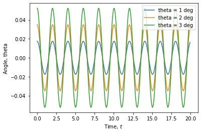

```python
from scipy.integrate import solve_ivp
import matplotlib.pyplot as plt
import numpy as np


thL = [1,2,3] #初期条件を３つ用意した。単位はdegreeです。
for i in range(len(thL)):

    g = 9.8  # 重力加速度(m/s^2)
    L = 1.0  # 振り子の長さ(m)

    # 運動方程式を解く
    def pend1(t, state):
        dydt = np.zeros_like(state)
        #dydtという二次元配列ををつくり、そこにすべて0を格納しろ。
        #最終的には、１列目には\theta、２列目にはωを格納する。

        dydt[0] = state[1] # dθ/dt = ω という式

        dydt[1] = -(g/L)*np.sin(state[0]) # dω/dt = -(g/L)sin(θ) という式

        #print(dydt[0])
        return dydt

    #設定
    t_span = [0,20] #時間 (s)
    dt = 0.05# 時間の間隔 (s)
    t = np.arange(t_span[0], t_span[1], dt)# 時間の間隔のarray作成 0から20までをdt間隔で１次元配列を作成。

    #初期状態設定 th1をループで回している。
    th1 = thL[i]# 角度 [deg]
    w1 = 0.0 # 初期角速度 [deg/s]
    state = np.radians([th1, w1])# 初期条件

    #微分方程式を解く
    sol = solve_ivp(pend1, t_span, state, t_eval=t)

    theta = sol.y[0] #y[0]＝θ、y[1]=ω
    omega = sol.y[1] #y[0]＝θ、y[1]=ω
    #この時点でsolの二次元配列には、θ(t)とω(t)が計算できており、ここではθ(t)を計算結果から取り出している。

    plt.plot(t, theta, '-', label="theta = "+str(th1)+" "+"deg")
    plt.legend(loc="upper right")
    plt.xlabel("Time, $t$")
    plt.ylabel("Angle, theta")
```

## 演習課題

$\theta$が小さいときは周期がほとんど変わらないと思います。$\theta$を大きくしたときに、周期がどうのように変化するか確かめてください。

また、可能であれば、その時の周期の値を求めてみてください。

難しければ、グラフから、どのように変化したのか、説明するだけでも構いません。

### 右辺が$t$のみの関数ではない、f(t, x(t))の場合

以下では、数値計算も万能ではない、という話をします。

今回の話とは、直接的には関係ないですが、興味がある人は読んでください。

右辺が$t$のみの関数とならない場合、$f(t)$を積分する、という直接期な形で微分方程式の解を表現することができません。

いわゆる、正しく積分できないため、微分方程式が解けない状態になり得ます。

正しく積分する、という意味は数学的にちゃんと説明すると非常に難しく、僕には説明できる能力もないため、なんとなくそのようなものだと思っておいてください。

たぶん今後の物理学の授業でも、解けるものしか扱わないので意外に思うかもしれませんが、実際の世の中は、解を関数で記述できない、解けない方程式が大多数です。

世の中の物理法則を支配するニュートン力学の方程式は明確なのに（微分方程式で書けている）、その解が関数で記述できないのです。

ただ素朴には（厳密には難しい話になるので踏み込みませんが）、解は実在して、運動方程式で記述した運動は、数値計算などによって逐次的に決定できるはずです。

逐次的というのは、微分方程式のように、ある時刻の物体の運動が、その直前の時刻の運動によって決まる、形で書けているため、初期状態を決めて、そこから、時間幅を小さくとって、次々と計算していくことで、どんな時刻の運動も予測できる、という意味です。

このような方法で十分正しく物体の運動を数値計算で記述できると思われた時期もありました。

**しかし、**世の中の物理法則はそんなに単純ではありませんでした。

ポアンカレは、運動方程式に従う系の運動でも、可積分（積分可能）と決めつけてはいけない、可積分の方程式はごくわずかで大部分は非可積分、つまり関数で記述できないことを指摘しました。ただ、関数で記述できなくとも、そんなに大きく運動が予想から外れないでないと考えたくなりますが、正しく積分できないという小さなズレが、積算すると、とんでもなく予想もつかないような挙動になることを指摘しました。このことをは、非可積分は予測可能な安定軌道をとらずにカオス的に振る舞う、とか言われます。

この有名な例は二重振り子です。 実験と、シミュレーションがありましたので、URLを載せておきます。僕も最初の資料で少し示しましたが、見たことのないような運動が見れると思います。

実験

https://youtu.be/25feOUNQB2Y

シミュレーション

https://youtu.be/QXf95_EKS6E